[figure not shown]

### **“Desafio Descubra as melhores notas de matemática do ENEM 2016”**

Este *notebook* apresenta a análise realizada para resolver o desafio da `#codenation` para ser aceito no `AceleraDev Data Science` que consiste em criar um modelo para prever a nota da prova de matemática de quem participou do ENEM 2016. A seguir será apresentado o fluxo de trabalho realizado.

#### **Workflow**

1. Definição do Problema
2. Carregamento dos Dados
3. Pré-Processamento dos Dados
4. Exploração dos Dados
5. Construção do Modelo
6. Avaliação
7. Conclusão

#### **1. Definição do Problema**

Antes da aplicação das mais diversas ferramentas e algoritmos para sair **“prevendo”** tudo por aí é importante o entendimento do problema e tipo de negócio que se está inserido. Este tipo de informação ajudará na conscientização e definição do problema e por fim na escolha das técnicas e ferramentas que melhor auxiliem na resolução do problema e na entrega de um bom resultado.

Nesse sentido, o contexto desse desafio gira em torno dos resultados do ENEM 2016 (disponíveis no arquivo train.csv). Este arquivo, e apenas ele, deve ser utilizado para todos os desafios. Qualquer dúvida a respeito das colunas, consulte o [Dicionário dos Microdados do Enem 2016](https://s3-us-west-1.amazonaws.com/acceleration-assets-highway/data-science/dicionario-de-dados.zip).

Muitas universidades brasileiras utilizam o ENEM para selecionar seus futuros alunos e alunas. Isto é feito com uma média ponderada das notas das provas de matemática, ciências da natureza, linguagens e códigos, ciências humanas e redação. Determine os 20 melhores colocados, por ordem, para os pesos abaixo:

- matemática: 3
- ciências da natureza: 2
- linguagens e códigos: 1.5
- ciências humanas: 1
- redação: 3

No arquivo test.csv crie um modelo para prever nota da prova de matemática (coluna **NU_NOTA_MT**) de quem participou do ENEM 2016.

#### **2. Carregamento dos Dados**

Os dados serão carregados a partir da função `read.csv` que é uma função nativa do R. Os arquivos podem ser encontrados no meu [repositório no github](https://github.com/tsantunes/CodeNation_AceleraDev_DataScience/tree/master/00_Desafio).

```r
dados.treino <- read.csv("train.csv")
dados.teste <- read.csv("test.csv")
```

#### **3. Pré-Processamento dos Dados**

Nesta etapa eu geralmente realizo algumas operações preliminares nos dados, como por exemplo, ajuste nos nomes das variáveis, formatações de datas, transformações nos tipos das variáveis e entre outras operações básicas para deixar o conjunto de dados com as características necessárias para a exploração dos dados.

Como foram fornecidos os arquivos de treino e teste e ambos arquivos apresentam dimensões diferentes vou realizar um `subset` a partir do arquivo de `teste` para uma primeira reducionalidade de variáveis. Essa decisão parte do pressuposto de que o arquivo fornecido para teste já é uma primeira indicação de quais variáveis podem ser utilizadas na construção do modelo.

```r
dim(dados.treino)
```

```
[1] 13730   167
```

```r
dim(dados.teste)
```

```
[1] 4576   47
```

> Cabe observar que nos dados de teste `dados.teste` a variável **NU_NOTA_MT** que se deseja prever os valores não é apresentada, pois o objetivo deste conjunto de dados é servir para testar o algorítmo e realizar as previsões.

Para a manipulação dos dados e gerar o novo conjunto de dados de treino `dados.treino.novo` irei utilizar o pacote `dplyr`.

```r
library(dplyr)

# criar um dataframe com os nomes das variaveis do conjunto de teste
nomes.colunas <- tibble(colnames(dados.teste))
nomes.colunas <- rbind(nomes.colunas, "NU_NOTA_MT")

# selecionar as variaveis com base no objeto nomes.colunas
dados.treino.novo <- dados.treino %>% select(nomes.colunas$`colnames(dados.teste)`)
```

#### **4. Exploração dos Dados**

A etapa de exploração dos dados, conhecida também como `EDA (Exploratory Data Analysis)`, é uma das etapas de grande importância em `data science`. É a partir dela que consguimos obter `insights` e entender como os dados estão distribuídos, descobrir padrões, identificar anomalias, testar hipóteses, checar premissas e sumarizar as estatísticas dos dados em tabelas e/ou gráficos.

Inicialmente iremos verificar se existem dados faltates nos dados de treino. Em seguida iremos verificar a estrutura dos dados e a sumário de informações iniciais.

```r
# checar a existência de registros faltantes (NAs)
sum(is.na(dados.treino.novo))
```

```
[1] 12938
```

Visto que existem dados nulos nos dados de treino podemos usar uma das três abordagens a seguir para tratar os casos faltantes:

1. Excluir os dados nulos do dataset. O que poderia diminuir drasticamente as amostras para treinar o modelo;
2. Substituir os valores nulos por zeros. O que conserva o número de amostras do dataset.
3. Substituir os valores nulos com o valor da média das features. O que conserva o número de amostras do dataset.

```r
# retirar registros faltantes e mudar o tipo das variáveis SG_UF_RESIDENCIA e TP_SEXO
library(tidyr)

dados.treino.novo <- dados.treino.novo %>% drop_na(NU_NOTA_LC, NU_NOTA_CH) %>%
        mutate(SG_UF_RESIDENCIA = as.factor(SG_UF_RESIDENCIA),
               TP_SEXO = as.factor(TP_SEXO))

# checar as transformações
summary(dados.treino.novo)
```

[output not shown]

A seguir iremos realizar uma análise exploratória de correlação entre as variáveis. Com base nos dados de treino vamos selecionar algumas das variáveis que podem apresentar forte correlação com a variável *target* que queremos prever e servir como um primeiro direcionador de quais variáveis considerar no modelo.

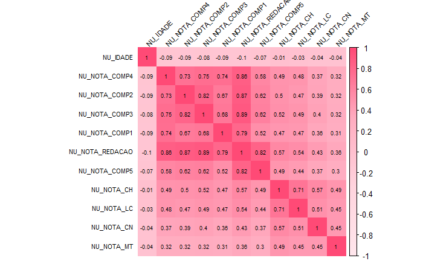

```r
# subset com os dados de treino
dados.corr <- dados.treino.novo %>% select(NU_NOTA_CN,NU_NOTA_CH,
                                           NU_NOTA_LC,NU_NOTA_COMP1,
                                           NU_NOTA_COMP2, NU_NOTA_COMP3,
                                           NU_NOTA_COMP4, NU_NOTA_COMP5,
                                           NU_NOTA_REDACAO, NU_NOTA_MT, NU_IDADE)
# criação da matriz de correlação
matriz.corr <- cor(dados.corr, method="spearman")

library(corrplot)
# cores do gráfico
col <- colorRampPalette(c("#ffe7ed", "#ffd4de","#ffacc0","#ff4a76"))
# gráfico de correlação
corrplot(matriz.corr, method="color", col=col(200),
         type="full", order="AOE",
         addCoef.col = "black",
         tl.col="black", tl.srt=45,
         tl.cex = 0.7, number.font = 0.6, number.cex = 0.55)
```

Para concluir a fase exploratória dos dados iremos realizar e observar a análise das estatísticas descritivas das variáveis relacionadas com as notas dos alunos.

|  | vars | n | mean | sd | median | trimmed | mad | min | max | range | skew | kurtosis | se |
| --- | --- | --- | --- | --- | --- | --- | --- | --- | --- | --- | --- | --- | --- |
| NU_NOTA_CN | 1 | 10097 | 473.91 | 71.10 | 460.4 | 467.43 | 67.01 | 0 | 806.4 | 806.4 | 0.68 | 1.53 | 0.71 |
| NU_NOTA_CH | 2 | 10097 | 530.35 | 73.53 | 532.6 | 531.33 | 75.02 | 0 | 807.0 | 807.0 | -0.14 | 0.31 | 0.73 |
| NU_NOTA_LC | 3 | 10097 | 516.67 | 68.44 | 521.1 | 517.89 | 70.57 | 0 | 763.6 | 763.6 | -0.35 | 1.35 | 0.68 |
| NU_NOTA_COMP1 | 4 | 10097 | 119.88 | 29.77 | 120.0 | 122.34 | 29.65 | 0 | 200.0 | 200.0 | -1.43 | 4.53 | 0.30 |
| NU_NOTA_COMP2 | 5 | 10097 | 112.00 | 33.68 | 120.0 | 113.06 | 29.65 | 0 | 200.0 | 200.0 | -0.63 | 1.94 | 0.34 |
| NU_NOTA_COMP3 | 6 | 10097 | 106.91 | 34.29 | 120.0 | 106.99 | 29.65 | 0 | 200.0 | 200.0 | -0.36 | 1.48 | 0.34 |
| NU_NOTA_COMP4 | 7 | 10097 | 113.21 | 33.41 | 120.0 | 113.87 | 29.65 | 0 | 200.0 | 200.0 | -0.62 | 2.26 | 0.33 |
| NU_NOTA_COMP5 | 8 | 10097 | 77.46 | 43.06 | 80.0 | 76.48 | 59.30 | 0 | 200.0 | 200.0 | 0.23 | -0.36 | 0.43 |
| NU_NOTA_REDACAO | 9 | 10097 | 529.45 | 154.00 | 540.0 | 532.51 | 118.61 | 0 | 1000.0 | 1000.0 | -0.57 | 2.24 | 1.53 |
| NU_NOTA_MT | 10 | 10097 | 482.65 | 99.69 | 461.3 | 472.05 | 89.40 | 0 | 952.0 | 952.0 | 0.93 | 1.37 | 0.99 |

[output cut: 1 more lines]

#### **5. Construção do Modelo**

Considerando que o objetivo é prever o nota da prova de matemática a partir das notas das demais provas iremos usar a técnica de Regressão Linear que é uma técnica amplamente utilizada e aceita para previsão de dados numéricos. A Seguir é apresentado a construção e teste dos 5 modelos utilizados para a análise dos resultados.

O objetivo é testar a relação entre as variáveis e por fim será escolhido o modelo que melhor descrever o comportamento da nota de matemática em relação as demais variáveis. Em seguida, no próximo item são apresentadas as métricas de avaliação para cada um dos modelos.

##### **MODELO 1**

```r
# modelo 1
modelo1 <- lm(NU_NOTA_MT~NU_NOTA_CN+NU_NOTA_CH+NU_NOTA_LC+NU_NOTA_COMP1+
                      NU_NOTA_COMP2+NU_NOTA_COMP3+NU_NOTA_COMP4+NU_NOTA_COMP5+
                      NU_NOTA_REDACAO+NU_IDADE+TP_SEXO+SG_UF_RESIDENCIA,
              data = dados.treino.novo)

summary(modelo1)
```

```
Call:
lm(formula = NU_NOTA_MT ~ NU_NOTA_CN + NU_NOTA_CH + NU_NOTA_LC +
    NU_NOTA_COMP1 + NU_NOTA_COMP2 + NU_NOTA_COMP3 + NU_NOTA_COMP4 +
    NU_NOTA_COMP5 + NU_NOTA_REDACAO + NU_IDADE + TP_SEXO + SG_UF_RESIDENCIA,
    data = dados.treino.novo)

Residuals:
    Min      1Q  Median      3Q     Max
-446.62  -51.88   -5.20   48.45  344.34

Coefficients: (1 not defined because of singularities)
                    Estimate Std. Error t value Pr(>|t|)
(Intercept)         13.23159   13.24709   0.999  0.31790
NU_NOTA_CN           0.49827    0.01411  35.305  < 2e-16 ***
NU_NOTA_CH           0.21780    0.01616  13.479  < 2e-16 ***
NU_NOTA_LC           0.20837    0.01614  12.912  < 2e-16 ***
NU_NOTA_COMP1       -0.01957    0.04710  -0.416  0.67777
NU_NOTA_COMP2       -0.03242    0.05003  -0.648  0.51705
NU_NOTA_COMP3        0.02453    0.05153   0.476  0.63406
NU_NOTA_COMP4        0.13460    0.04924   2.733  0.00628 **
NU_NOTA_COMP5        0.05526    0.02502   2.208  0.02725 *
NU_NOTA_REDACAO           NA         NA      NA       NA
NU_IDADE            -0.55287    0.12226  -4.522 6.19e-06 ***
TP_SEXOM            25.67347    1.60827  15.963  < 2e-16 ***
SG_UF_RESIDENCIAAL -15.88817   12.44262  -1.277  0.20166
SG_UF_RESIDENCIAAM  -2.04375   12.41645  -0.165  0.86926
SG_UF_RESIDENCIAAP -18.76915   15.20454  -1.234  0.21707
SG_UF_RESIDENCIABA  -6.59515   11.35892  -0.581  0.56151
SG_UF_RESIDENCIACE -10.87312   11.17063  -0.973  0.33039
SG_UF_RESIDENCIADF   5.34679   12.50693   0.428  0.66902
SG_UF_RESIDENCIAES -13.16291   12.15527  -1.083  0.27888
SG_UF_RESIDENCIAGO  -9.16411   11.64256  -0.787  0.43123
SG_UF_RESIDENCIAMA -13.08386   11.52272  -1.135  0.25620
SG_UF_RESIDENCIAMG   5.15660   11.23474   0.459  0.64625
SG_UF_RESIDENCIAMS  -2.87172   12.83039  -0.224  0.82290
SG_UF_RESIDENCIAMT  -0.13533   12.28070  -0.011  0.99121
SG_UF_RESIDENCIAPA -13.41909   11.52051  -1.165  0.24413
SG_UF_RESIDENCIAPB  -9.41927   11.97437  -0.787  0.43152
SG_UF_RESIDENCIAPE -14.60317   11.52004  -1.268  0.20496
SG_UF_RESIDENCIAPI -11.96506   12.05188  -0.993  0.32083
SG_UF_RESIDENCIAPR   3.82436   11.54056   0.331  0.74036
SG_UF_RESIDENCIARJ   2.85113   11.45547   0.249  0.80345
SG_UF_RESIDENCIARN   1.10834   12.31031   0.090  0.92826
SG_UF_RESIDENCIARO  -8.51104   13.83717  -0.615  0.53851
SG_UF_RESIDENCIARR  -0.40044   19.56339  -0.020  0.98367
SG_UF_RESIDENCIARS   2.96178   11.64719   0.254  0.79928
SG_UF_RESIDENCIASC   0.15484   12.17024   0.013  0.98985
SG_UF_RESIDENCIASE  -5.12991   12.59768  -0.407  0.68386
SG_UF_RESIDENCIASP   0.57332   11.15148   0.051  0.95900
SG_UF_RESIDENCIATO  -9.88708   12.80724  -0.772  0.44014
---
Signif. codes:  0 ‘***’ 0.001 ‘**’ 0.01 ‘*’ 0.05 ‘.’ 0.1 ‘ ’ 1

Residual standard error: 75.94 on 10060 degrees of freedom
Multiple R-squared:  0.4218,    Adjusted R-squared:  0.4197
F-statistic: 203.8 on 36 and 10060 DF,  p-value: < 2.2e-16
```

```r
dados.treino.novo$MODEL1 <- predict(modelo1, newdata = dados.treino.novo)
```

[output not shown]

```r
actuals_preds <- data.frame(cbind(actuals=dados.treino.novo$NU_NOTA_MT,
                                  predicteds=dados.treino.novo$MODEL1))
cor(actuals_preds)
```

```
            actuals predicteds
actuals    1.000000   0.649444
predicteds 0.649444   1.000000
```

##### **MODELO 2**

```r
# modelo 2
modelo2 <- lm(NU_NOTA_MT~NU_NOTA_CN+NU_NOTA_CH+NU_NOTA_LC+NU_NOTA_COMP1+
                      NU_NOTA_COMP2+NU_NOTA_COMP3+NU_NOTA_COMP4+NU_NOTA_COMP5+
                      NU_IDADE+TP_SEXO,
              data = dados.treino.novo)

summary(modelo2)
```

```
Call:
lm(formula = NU_NOTA_MT ~ NU_NOTA_CN + NU_NOTA_CH + NU_NOTA_LC +
    NU_NOTA_COMP1 + NU_NOTA_COMP2 + NU_NOTA_COMP3 + NU_NOTA_COMP4 +
    NU_NOTA_COMP5 + NU_IDADE + TP_SEXO, data = dados.treino.novo)

Residuals:
    Min      1Q  Median      3Q     Max
-449.07  -52.76   -5.04   48.95  357.61

Coefficients:
               Estimate Std. Error t value Pr(>|t|)
(Intercept)   -3.921121   7.346613  -0.534  0.59354
NU_NOTA_CN     0.501227   0.014130  35.474  < 2e-16 ***
NU_NOTA_CH     0.223933   0.016133  13.880  < 2e-16 ***
NU_NOTA_LC     0.222340   0.016050  13.853  < 2e-16 ***
NU_NOTA_COMP1  0.001436   0.047089   0.030  0.97567
NU_NOTA_COMP2 -0.032879   0.050125  -0.656  0.51187
NU_NOTA_COMP3  0.011779   0.051592   0.228  0.81941
NU_NOTA_COMP4  0.133785   0.049315   2.713  0.00668 **
NU_NOTA_COMP5  0.049238   0.025015   1.968  0.04906 *
NU_IDADE      -0.534567   0.120765  -4.426 9.68e-06 ***
TP_SEXOM      25.341260   1.609120  15.749  < 2e-16 ***
---
Signif. codes:  0 ‘***’ 0.001 ‘**’ 0.01 ‘*’ 0.05 ‘.’ 0.1 ‘ ’ 1

Residual standard error: 76.16 on 10086 degrees of freedom
Multiple R-squared:  0.417, Adjusted R-squared:  0.4164
F-statistic: 721.3 on 10 and 10086 DF,  p-value: < 2.2e-16
```

```r
dados.treino.novo$MODEL2 <- predict(modelo2, newdata = dados.treino.novo)
actuals_preds2 <- data.frame(cbind(actuals=dados.treino.novo$NU_NOTA_MT,
                                  predicteds=dados.treino.novo$MODEL2))

cor(actuals_preds2)
```

```
             actuals predicteds
actuals    1.0000000  0.6457223
predicteds 0.6457223  1.0000000
```

##### **MODELO 3**

```r
# modelo 3
modelo3 <- lm(NU_NOTA_MT~NU_NOTA_CN+NU_NOTA_CH+NU_NOTA_LC+NU_NOTA_COMP4+NU_IDADE+TP_SEXO,
              data = dados.treino.novo)

summary(modelo3)
```

```
Call:
lm(formula = NU_NOTA_MT ~ NU_NOTA_CN + NU_NOTA_CH + NU_NOTA_LC +
    NU_NOTA_COMP4 + NU_IDADE + TP_SEXO, data = dados.treino.novo)

Residuals:
    Min      1Q  Median      3Q     Max
-451.23  -52.88   -5.28   49.24  358.73

Coefficients:
              Estimate Std. Error t value Pr(>|t|)
(Intercept)   -8.04736    6.90908  -1.165    0.244
NU_NOTA_CN     0.50325    0.01405  35.809  < 2e-16 ***
NU_NOTA_CH     0.22804    0.01591  14.330  < 2e-16 ***
NU_NOTA_LC     0.22372    0.01601  13.974  < 2e-16 ***
NU_NOTA_COMP4  0.15077    0.02732   5.518 3.51e-08 ***
NU_IDADE      -0.53903    0.12058  -4.470 7.89e-06 ***
TP_SEXOM      25.35952    1.60398  15.810  < 2e-16 ***
---
Signif. codes:  0 ‘***’ 0.001 ‘**’ 0.01 ‘*’ 0.05 ‘.’ 0.1 ‘ ’ 1

Residual standard error: 76.16 on 10090 degrees of freedom
Multiple R-squared:  0.4167,    Adjusted R-squared:  0.4164
F-statistic:  1201 on 6 and 10090 DF,  p-value: < 2.2e-16
```

```r
dados.treino.novo$MODEL3 <- predict(modelo3, newdata = dados.treino.novo)
actuals_preds3 <- data.frame(cbind(actuals=dados.treino.novo$NU_NOTA_MT,
                                   predicteds=dados.treino.novo$MODEL3))

cor(actuals_preds3)
```

```
             actuals predicteds
actuals    1.0000000  0.6455369
predicteds 0.6455369  1.0000000
```

##### **MODELO 4**

```r
# modelo 4
modelo4 <- lm(NU_NOTA_MT~NU_NOTA_CN+NU_NOTA_CH+NU_NOTA_LC+NU_NOTA_COMP4+NU_IDADE+TP_SEXO+
                      Q001+Q002+Q006+Q024+Q027+Q047,
              data = dados.treino.novo)

summary(modelo4)
```

```
Call:
lm(formula = NU_NOTA_MT ~ NU_NOTA_CN + NU_NOTA_CH + NU_NOTA_LC +
    NU_NOTA_COMP4 + NU_IDADE + TP_SEXO + Q001 + Q002 + Q006 +
    Q024 + Q027 + Q047, data = dados.treino.novo)

Residuals:
    Min      1Q  Median      3Q     Max
-445.87  -50.70   -4.54   47.80  347.83

Coefficients:
               Estimate Std. Error t value Pr(>|t|)
(Intercept)    43.31705    9.23981   4.688 2.79e-06 ***
NU_NOTA_CN      0.43193    0.01426  30.285  < 2e-16 ***
NU_NOTA_CH      0.19403    0.01566  12.388  < 2e-16 ***
NU_NOTA_LC      0.18747    0.01584  11.838  < 2e-16 ***
NU_NOTA_COMP4   0.09780    0.02691   3.634 0.000280 ***
NU_IDADE       -0.31050    0.14734  -2.107 0.035102 *
TP_SEXOM       23.96782    1.58238  15.147  < 2e-16 ***
Q001B           0.77923    3.68418   0.212 0.832496
Q001C           3.63517    3.94884   0.921 0.357299
Q001D           2.12571    4.11765   0.516 0.605695
Q001E           4.54034    3.95726   1.147 0.251266
Q001F          14.09939    4.98205   2.830 0.004663 **
Q001G          19.29618    6.14958   3.138 0.001707 **
Q001H          -0.16024    4.35134  -0.037 0.970625
Q002B          -1.12542    4.51141  -0.249 0.803009
Q002C           1.25196    4.69129   0.267 0.789575
Q002D          -0.18453    4.75528  -0.039 0.969046
Q002E           3.54486    4.62898   0.766 0.443815
Q002F          10.60676    5.31515   1.996 0.046008 *
Q002G           3.85263    5.69688   0.676 0.498885
Q002H           2.12774    5.73792   0.371 0.710779
Q006B           1.64607    4.31255   0.382 0.702697
Q006C           4.24166    4.41497   0.961 0.336703
Q006D           7.47328    4.75514   1.572 0.116070
Q006E           5.98156    5.04327   1.186 0.235631
Q006F          12.56523    5.44527   2.308 0.021045 *
Q006G          17.36372    5.50584   3.154 0.001617 **
Q006H          21.81441    5.96838   3.655 0.000258 ***
Q006I          17.14556    6.84391   2.505 0.012253 *
```

[output cut: 20 more lines]

```
Q027I           5.69036    8.06867   0.705 0.480676
Q027J           5.26205   10.13229   0.519 0.603538
Q027K         -27.03869   11.77712  -2.296 0.021704 *
Q027L          19.32833   16.39617   1.179 0.238493
Q027M          -1.97609    9.11081  -0.217 0.828295
Q047B           2.39895    4.88216   0.491 0.623175
Q047C           0.55770    6.77667   0.082 0.934412
Q047D          20.64601    3.07468   6.715 1.98e-11 ***
Q047E          17.89280    4.75128   3.766 0.000167 ***
---
Signif. codes:  0 ‘***’ 0.001 ‘**’ 0.01 ‘*’ 0.05 ‘.’ 0.1 ‘ ’ 1

Residual standard error: 74.4 on 10039 degrees of freedom
Multiple R-squared:  0.4462,    Adjusted R-squared:  0.443
F-statistic: 141.9 on 57 and 10039 DF,  p-value: < 2.2e-16
```

```r
dados.treino.novo$MODEL4 <- predict(modelo4, newdata = dados.treino.novo)
actuals_preds4 <- data.frame(cbind(actuals=dados.treino.novo$NU_NOTA_MT,
                                   predicteds=dados.treino.novo$MODEL4))

cor(actuals_preds4)
```

```
            actuals predicteds
actuals    1.000000   0.667962
predicteds 0.667962   1.000000
```

##### **MODELO 5**

```r
# modelo 5
modelo5 <- lm(NU_NOTA_MT~NU_NOTA_CN+NU_NOTA_CH+NU_NOTA_LC+NU_NOTA_COMP4+NU_IDADE+TP_SEXO+
                      Q006+Q047,
              data = dados.treino.novo)

summary(modelo5)
```

```
Call:
lm(formula = NU_NOTA_MT ~ NU_NOTA_CN + NU_NOTA_CH + NU_NOTA_LC +
    NU_NOTA_COMP4 + NU_IDADE + TP_SEXO + Q006 + Q047, data = dados.treino.novo)

Residuals:
    Min      1Q  Median      3Q     Max
-446.91  -50.91   -4.76   48.25  346.71

Coefficients:
              Estimate Std. Error t value Pr(>|t|)
(Intercept)   40.71767    8.18584   4.974 6.66e-07 ***
NU_NOTA_CN     0.43615    0.01425  30.599  < 2e-16 ***
NU_NOTA_CH     0.19810    0.01568  12.631  < 2e-16 ***
NU_NOTA_LC     0.19744    0.01580  12.497  < 2e-16 ***
NU_NOTA_COMP4  0.10410    0.02691   3.868 0.000110 ***
NU_IDADE      -0.38317    0.11899  -3.220 0.001285 **
TP_SEXOM      24.89092    1.57537  15.800  < 2e-16 ***
Q006B          2.02796    4.31750   0.470 0.638575
Q006C          7.65158    4.37526   1.749 0.080351 .
Q006D         12.79379    4.68135   2.733 0.006288 **
Q006E         12.53033    4.95179   2.530 0.011406 *
Q006F         19.50035    5.34412   3.649 0.000265 ***
Q006G         26.09850    5.37227   4.858 1.20e-06 ***
Q006H         30.91402    5.81616   5.315 1.09e-07 ***
Q006I         27.90286    6.67936   4.177 2.97e-05 ***
Q006J         29.55432    7.64306   3.867 0.000111 ***
Q006K         55.71761    9.53205   5.845 5.21e-09 ***
Q006L         43.76107   10.96613   3.991 6.64e-05 ***
Q006M         63.46668   12.04315   5.270 1.39e-07 ***
Q006N         41.52500    9.36711   4.433 9.39e-06 ***
Q006O         45.52446   11.31473   4.023 5.78e-05 ***
Q006P         70.84370   10.65261   6.650 3.08e-11 ***
Q006Q         72.74949   11.30184   6.437 1.27e-10 ***
Q047B          4.24757    4.87271   0.872 0.383390
Q047C          3.84818    6.77125   0.568 0.569836
Q047D         22.66499    3.00560   7.541 5.07e-14 ***
Q047E         20.59452    4.72569   4.358 1.33e-05 ***
---
Signif. codes:  0 ‘***’ 0.001 ‘**’ 0.01 ‘*’ 0.05 ‘.’ 0.1 ‘ ’ 1

Residual standard error: 74.65 on 10070 degrees of freedom
Multiple R-squared:  0.4407,    Adjusted R-squared:  0.4393
F-statistic: 305.2 on 26 and 10070 DF,  p-value: < 2.2e-16
```

```r
dados.treino.novo$MODEL5 <- predict(modelo5, newdata = dados.treino.novo)
actuals_preds5 <- data.frame(cbind(actuals=dados.treino.novo$NU_NOTA_MT,
                                   predicteds=dados.treino.novo$MODEL5))

cor(actuals_preds5)
```

```
             actuals predicteds
actuals    1.0000000  0.6638739
predicteds 0.6638739  1.0000000
```

#### **6. Avaliação**

Para a avaliação dos modelos irei utilizar o `package DMwR` desenvolvido pelo autor do livro *“Data Mining with R, learning with case studies”*, Luis Torgo. O objetivo desta etapa é avaliar as principais métricas e selecionar o modelo que apresentar o menor erro de previsão.

Nesse sentido o modelo que apresentou o melhor resultado foi o `modelo 4` com RMSE de 74.18 e MAE de 58.54.

```r
library(DMwR)

regr.eval(actuals_preds$actuals, actuals_preds$predicteds)
```

```
       mae        mse       rmse       mape
  59.84422 5745.37962   75.79828        Inf
```

```r
regr.eval(actuals_preds2$actuals, actuals_preds2$predicteds)
```

```
       mae        mse       rmse       mape
  60.17920 5793.27501   76.11357        Inf
```

```r
regr.eval(actuals_preds3$actuals, actuals_preds3$predicteds)
```

```
       mae        mse       rmse       mape
  60.18670 5795.65388   76.12919        Inf
```

```r
regr.eval(actuals_preds4$actuals, actuals_preds4$predicteds)
```

```
       mae        mse       rmse       mape
  58.54603 5502.97689   74.18205        Inf
```

```r
regr.eval(actuals_preds5$actuals, actuals_preds5$predicteds)
```

```
       mae        mse       rmse       mape
  58.89959 5557.07686   74.54580        Inf
```

#### **7. Conclusão**

Por fim, nos dados de teste é criada a variável `NU_NOTA_MT` para armazenar as previsões realizadas a partir do modelo 4. Em seguida é gerado o arquivo de resposta `answer.csv`.

```r
# criação da variável para armazenar a nota de matemática
dados.teste$NU_NOTA_MT <- predict(modelo4, newdata = dados.teste)
# subset para criar o arquivo de respostas
# Foi realizado o input de 0 (zero) para as notas faltantes
answer <- dados.teste %>% select(NU_INSCRICAO, NU_NOTA_MT) %>%
        mutate(NU_NOTA_MT = ifelse(is.na(NU_NOTA_MT), 0, NU_NOTA_MT))
# comando para salvar os dados em um arquivo CSV para submeter na plataforma
write.csv(answer, "answer.csv", row.names = F)
```